# VAE-CycleGAN

## 4 Results

### 4.1 CycleGAN Results

Below are the results of the images generated from a CycleGAN model - with out probabilistic sampling from the latent space.

In Figure (a) below, the first row shows the input satellite pictures followed by generated maps for the satellite pictures in the second row. The third row shows the input maps followed by generated satellite pictures in the fourth row.

In Figure (b) below, the first row shows the input satellite pictures followed by generated/fake maps for the satellite pictures in the second row. The third row shows the generated satellite pictures from the fake maps.The fourth row shows the generated maps from the fake satellite pictures.

Table 1

Aerial Views to Maps (X $\to$ Y $\&$ Y $\to$ X )

Aerial Views to Maps (X $\to$ Y $\to$ X’$\to$ Y’)

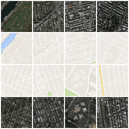

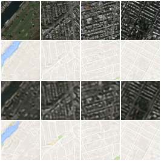

(a)

(b)

CycleGAN: Satellite to Maps Transformation

### 4.2 VAE-CycleGAN Results

Below are the results of the images generated from a Variation Autoencoder CycleGAN model - with probabilistic sampling from the latent space.

Table 2

Aerial Views to Maps (X $\to$ Y $\&$ Y $\to$ X )

Aerial Views to Maps (X $\to$ Y $\to$ X’$\to$ Y’)

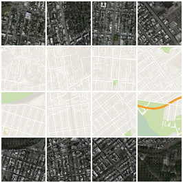

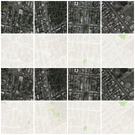

(a)

(b)

VAE-CycleGAN: Satellite to Maps Transformation

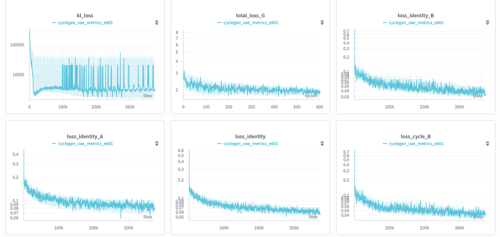

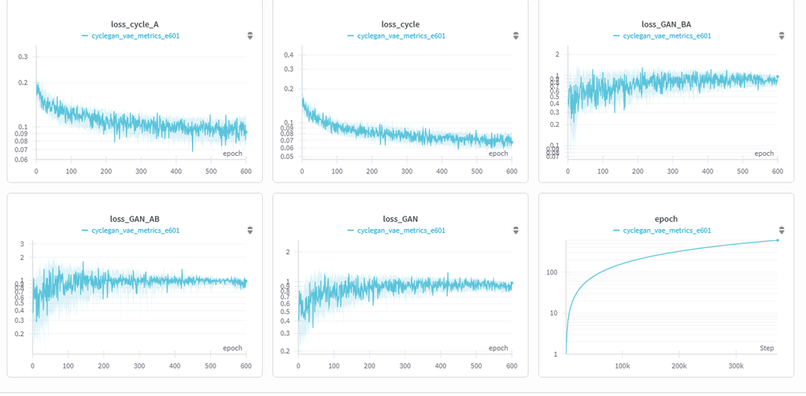

### 4.3 Metrics

**Compression Rate**

Compression rate measures how much the input is reduced in spatial dimensions while increasing channel depth. It’s calculated as:

$$\text{Compression Rate} = \frac{\text{Latent Spatial Size}}{\text{Input Spatial Size}} \times \frac{\text{Input Channels}}{\text{Final Channels}}$$

The latent representation in the VAE-CycleGAN model is a flat vector (not spatial), Therefore, we the spatial reduction factor and channel expansion/reduction are described separately.

**Spatial Compression**

Input Spatial Size: 64×64=4096 pixels.

Final Encoder Output: 16×16=256 pixels.

$$\text{Spatial Compression Factor}: \frac{64 \times 64}{16 \times 16} = 16 \times$$

*(The image is compressed to 1/16th of its original spatial area.)*

**Channel Expansion**

Input Channels: 3 (RGB).

Final Encoder Channels: 256.

$$\text{Channel Expansion Factor}: \frac{256}{3} \approx 85.33 \times$$

**AE-CycleGAN**

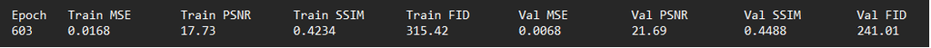

**VAE-CycleGAN**

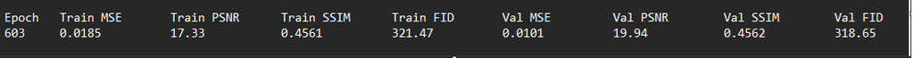

Goodfellow, Ian J, Jean Pouget-Abadie, Mehdi Mirza, Bing Xu, David Warde-Farley, Sherjil Ozair, Aaron Courville, and Yoshua Bengio. 2014. “Generative Adversarial Nets.” *Advances in Neural Information Processing Systems* 27.

Isola, Phillip, Jun-Yan Zhu, Tinghui Zhou, and Alexei A Efros. 2017. “Image-to-Image Translation with Conditional Adversarial Networks.” In *Proceedings of the IEEE Conference on Computer Vision and Pattern Recognition*, 1125–34.

Kingma, Diederik P, Max Welling, et al. 2013. “Auto-Encoding Variational Bayes.” Banff, Canada.

Larsen, Anders Boesen Lindbo, Søren Kaae Sønderby, Hugo Larochelle, and Ole Winther. 2016. “Autoencoding Beyond Pixels Using a Learned Similarity Metric.” arXiv. https://doi.org/10.48550/arXiv.1512.09300.

Li, Pengzhi, Yan Pei, and Jianqiang Li. 2023. “A Comprehensive Survey on Design and Application of Autoencoder in Deep Learning.” *Applied Soft Computing* 138: 110176.

Razghandi, Mina, Hao Zhou, Melike Erol-Kantarci, and Damla Turgut. 2022. “Variational Autoencoder Generative Adversarial Network for Synthetic Data Generation in Smart Home.” In *ICC 2022-IEEE International Conference on Communications*, 4781–86. IEEE.

Sharma, Aditya. 2023. “A Deep Dive into Variational Autoencoders with PyTorch.” *PyImageSearch*.

“The Reparameterization Trick.” n.d. Accessed July 19, 2025.

“Variational Autoencoders.” 2023. *Matthew N. Bernstein*.

Weng, Lilian. 2018. “From Autoencoder to Beta-VAE.” August 12, 2018.

Yan, Jian’en, Haihui Huang, Kairan Yang, Haiyan Xu, and Yanling Li. 2025. “Synthetic Data for Enhanced Privacy: A VAE-GAN Approach Against Membership Inference Attacks.” *Knowledge-Based Systems* 309: 112899.

Zhai, Junhai, Sufang Zhang, Junfen Chen, and Qiang He. 2018. “Autoencoder and Its Various Variants.” In *2018 IEEE International Conference on Systems, Man, and Cybernetics (SMC)*, 415–19. IEEE.

Zhu, Jun-Yan, Taesung Park, Phillip Isola, and Alexei A Efros. 2017. “Unpaired Image-to-Image Translation Using Cycle-Consistent Adversarial Networks.” In *Proceedings of the IEEE International Conference on Computer Vision*, 2223–32.

Zhu, Miaomiao, Shengrong Gong, Zhenjiang Qian, and Lifeng Zhang. 2019. “A Brief Review on Cycle Generative Adversarial Networks.” In *The 7th IIAE International Conference on Intelligent Systems and Image Processing (ICISIP)*, 235–42.